# **Relatório de Análise do Modulo 7: Contratações**

## O objetivo deste relatório é analisar de forma integrada os dados extraídos dos seis endpoints disponíveis, abrangendo contratações, itens das contratações e resultados dos itens. Busca-se compreender o comportamento das contratações públicas a partir de diferentes perspectivas, incluindo modalidades, valores estimados e homologados, órgãos contratantes e amparo legal. Além disso, o estudo investiga características dos itens, como frequência, categorias, orçamentos sigilosos e resultados obtidos.

# **Análise de Contratações Públicas Endpoints 1 e 1.1**

## Aqui será apresentado a análise detalhada das contratações públicas com base nos dados extraídos do sistema PNCP. Foram exploradas distribuições, comparações de valores, volume de contratações por órgão, amparo legal e sazonalidade.

# **1.1.Distribuição de Contratações por Modalidade**

Este gráfico mostra a quantidade de contratações para cada modalidade.

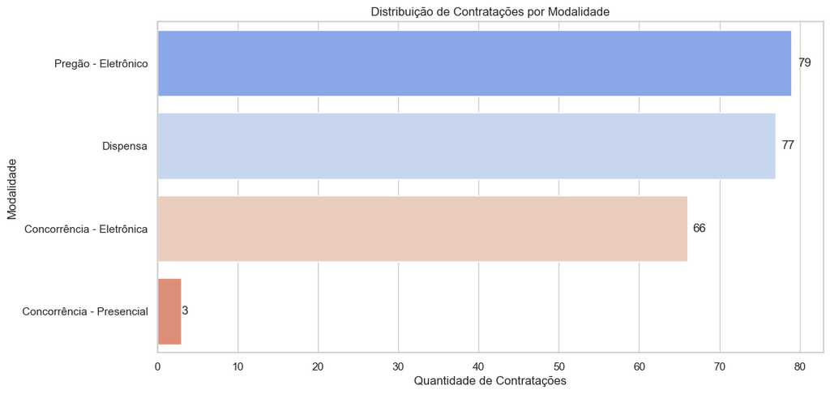

A análise mostrou a frequência das modalidades de licitação utilizadas onde é possível identificar quais modalidades são mais recorrentes, permitindo entender tendências de contratação no órgão público.

# **1.2.Comparação entre Valores Estimados e Homologados**

Este gráfico de linha mostra a evolução dos valores estimados e homologados ao longo do tempo.

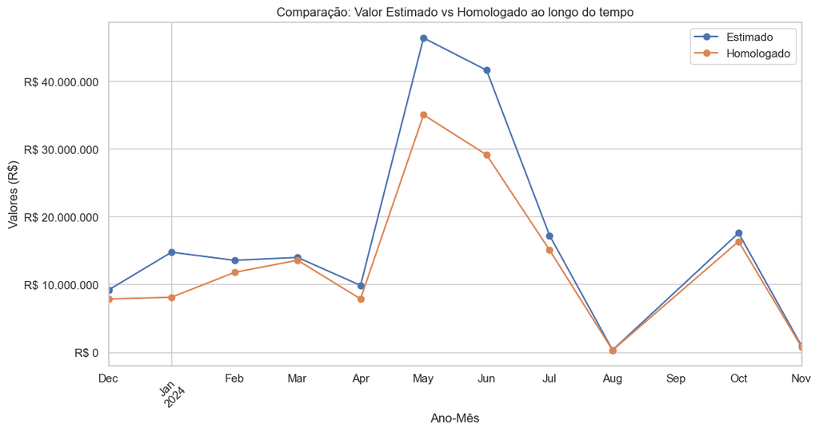

# **1.3.Órgãos com Maior Volume de Contratações**

Este gráfico mostra os órgãos com mais contratações registradas.

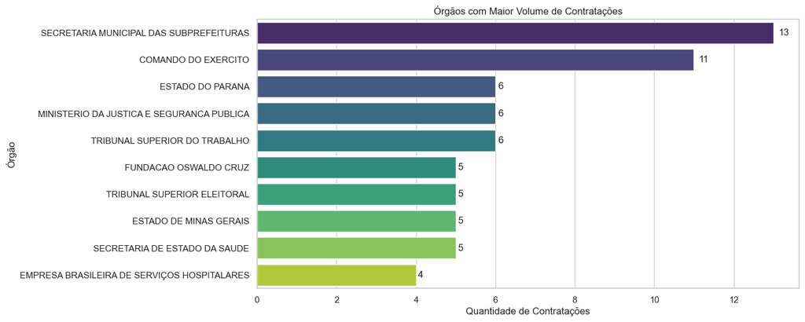

Este gráfico apresenta a contagem das contratações feitas pelos orgãos e apresenta os que mais houveram quantidades de contratações. Identifica os órgãos mais ativos em processos licitatórios, auxiliando no planejamento de auditorias e alocação de recursos.

# **1.4.Valores Homologados por Amparo Legal**

Este gráfico apresenta o valor total homologado de acordo com o amparo legal.

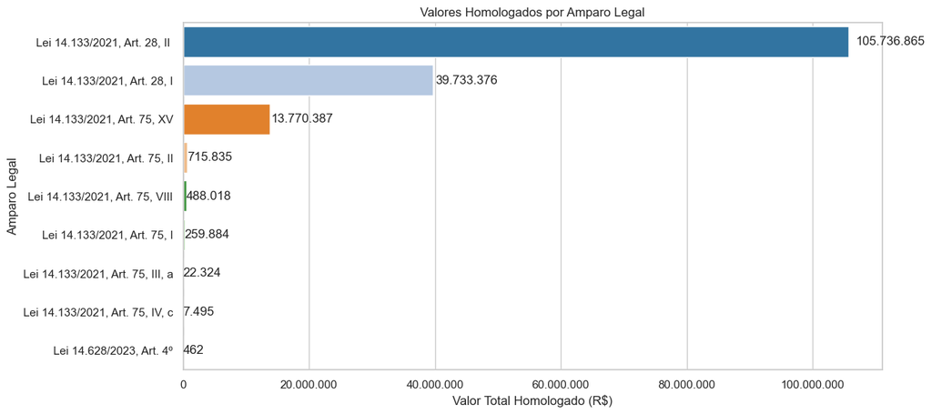

Os valores homologados foram agrupados por amparoLegalNome para identificar quais leis ou artigos fundamentam os maiores valores contratados. Permite identificar padrões de aplicação da legislação em contratações de alto valor.

# **1.5.Sazonalidade das Contratações**

Este gráfico mostra a distribuição das contratações por mês de abertura, indicando possíveis tendências sazonais.

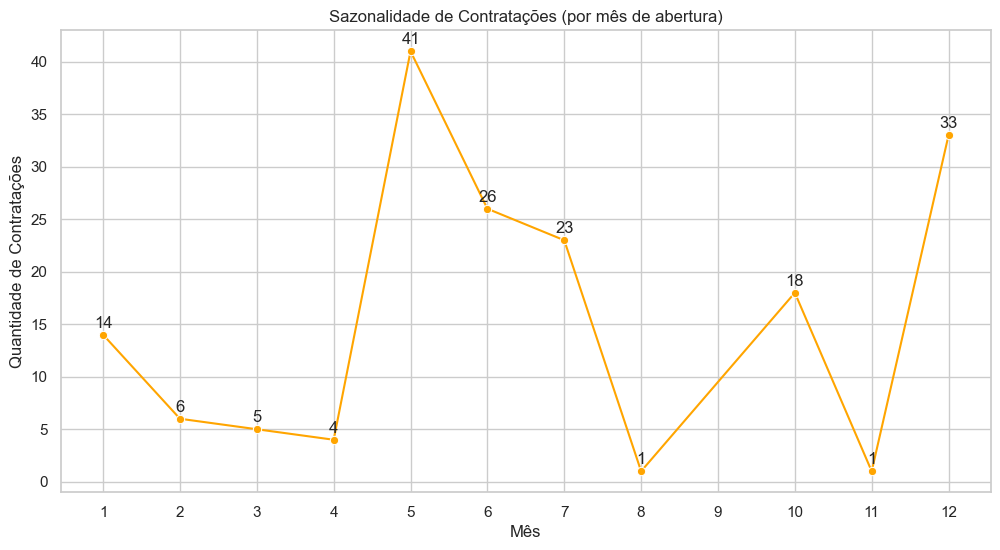

A análise da sazonalidade utiliza o mês de abertura da proposta (dataAberturaPropostaPncp) para identificar padrões temporais na atividade de contratações. Ajuda a planejar recursos e equipes de gestão de contratos nos períodos de maior demanda.

# **Análise de Itens de Contratações Endpoints 2 e 2.1**

## Aqui será apresentado a análise detalhada dos itens de contratações públicas, destacando frequência, valores unitários médios, sigilo orçamentário, resultados das licitações e a proporção entre materiais e serviços.

# **2.1.Itens mais Frequentes**

Este gráfico mostra os itens que aparecem com mais frequencia nas contratações.

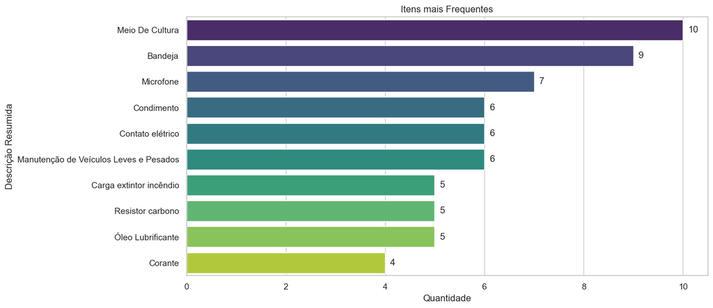

Foram contabilizados os itens mais recorrentes nas contratações, com base na coluna descricaoResumida. Pode apoiar fornecedores na estratégia de entrada em licitações, concentrando esforços em itens mais procurados.

# **2.2.Valor Médio Unitário por Categoria**

Mostra o valor médio estimado por categoria

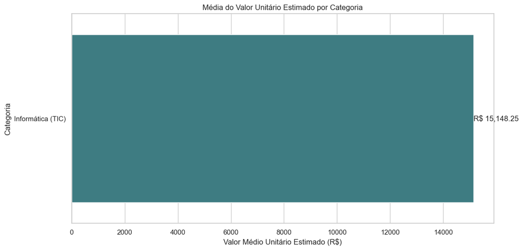

Foi calculada a média do valorUnitarioEstimado agrupada por itemCategoriaNome. No caso da base de dados utilizada só foi achado a categoria Informática (TIC).

# **2.3.Evolução Mensal da Média do Valor Unitário Estimado**

Gráfico que mostra a evolução mensal do valor unitário estimado por categoria.

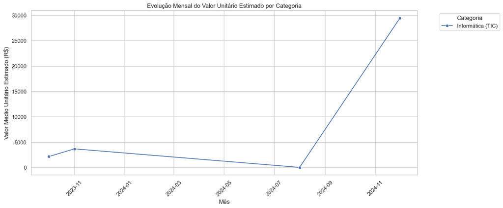

A média mensal de valorUnitarioEstimado foi analisada ao longo do tempo (dataInclusaoPncp), segmentada por itemCategoriaNome. Permite observar tendências de preço ao longo do tempo, podendo indicar sazonalidade ou variações de mercado.

# **2.4.Proporção de Itens com Orçamento Sigiloso**

Gráfico comparando a proporção de itens sigilosos para não sigilosos

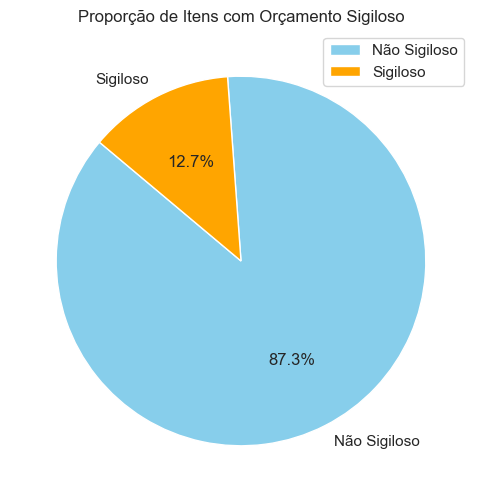

Foi calculada a proporção de itens cujo orçamento foi marcado como sigiloso (orcamentoSigiloso = true). Indica o nível de transparência nas compras públicas.

# **2.5.Proporção de Itens com Resultado x Sem Informação**

Gráfico que comparada a proporção de itens que retornam resultado verdadeiro e itens que não contem informação no resultado.

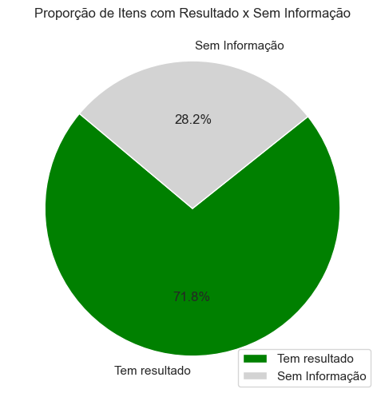

A coluna temResultado foi analisada para verificar quantos itens possuem resultado efetivo versus aqueles sem informação. Ajuda a avaliar o grau de conclusão das licitações.

# **2.6.Proporção de Itens: Material x Serviço**

Gráfico que comparada a proporção de material e serviços.

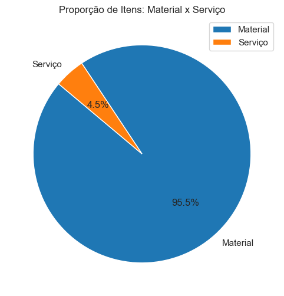

A coluna materialOuServicoNome foi analisada para diferenciar contratações de materiais e serviços.

# **Análise — Endpoints 3 e 3.1 Resultados de Itens Contratações**

# Os dados trazem resultados dos itens contratados (fornecedores vencedores, valores homologados, natureza jurídica, porte dos fornecedores, origem dos produtos/serviços, descontos aplicados, entre outros).

# **3.1.Principais Fornecedores**

Gráfico mostrando os principais fornecedores por valor homologado.

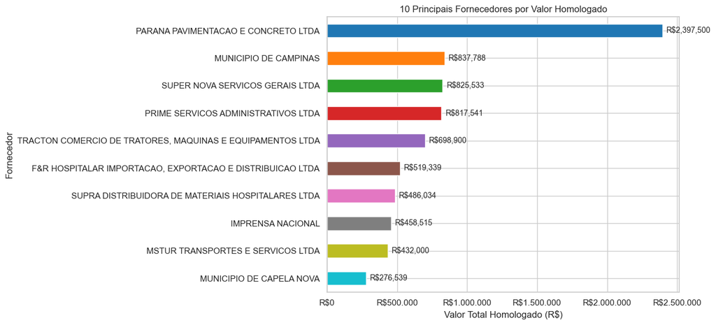

Agrupamento por nomeRazaoSocialFornecedor e soma de valorTotalHomologado. Exibição dos 10 maiores em gráfico de barras horizontais. Identifica fornecedores que receberam os maiores repasses por contratos (maior participação em termos financeiros).

# **3.2.Valores Homologados por Natureza Jurídica**

Gráfico mostrando ordenado mostrando gasto por tipo de entidade.

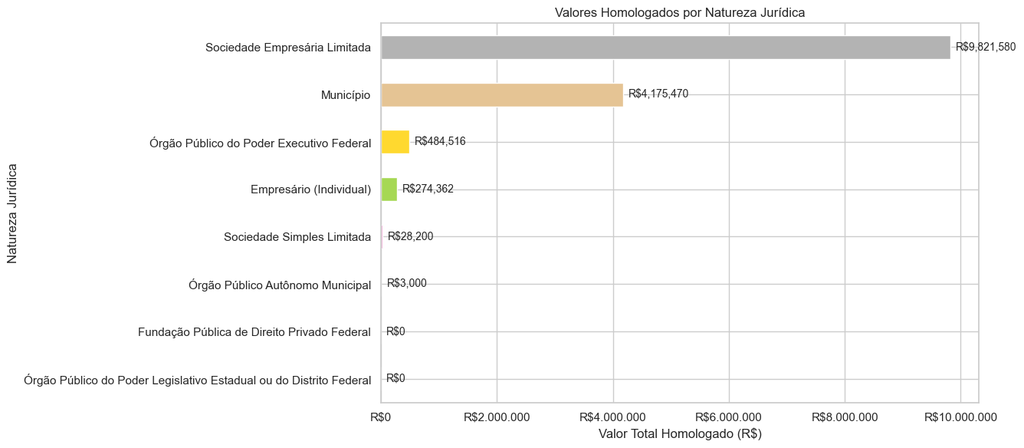

# **3.3.Distribuição de Valores Homologados para MPEs**

Gráfico filtrando e mostrando valores homologados apenas para MPEs

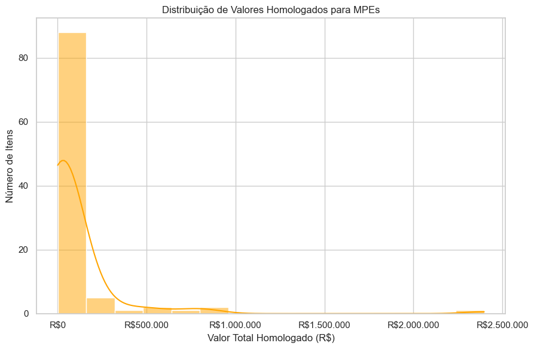

Filtragem por aplicacaoBeneficioMeepp == True e plotagem da distribuição dos valorTotalHomologado. Mostra a distribuição (concentração) dos valores homologados quando aplicou-se benefício a micro/pequenas empresas (MPEs).

# **3.4.Evolução do Valor Homologado ao Longo do Tempo**

Gráfico que mostra evolução do valor homologado ao longo do tempo

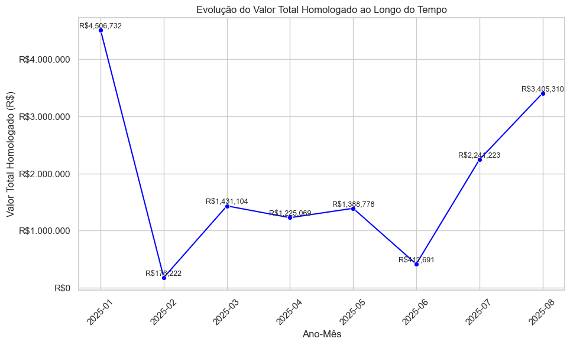

Agregação por ano_mes (extraído de dataResultadoPncp) somando valorTotalHomologado. Permite identificar tendências temporais: aumentos, quedas e sazonalidade no volume financeiro homologado.

# **3.5.País de Origem dos Produtos e Serviços**

Gráfico mostrando o país de Origem de produtos e Serviços

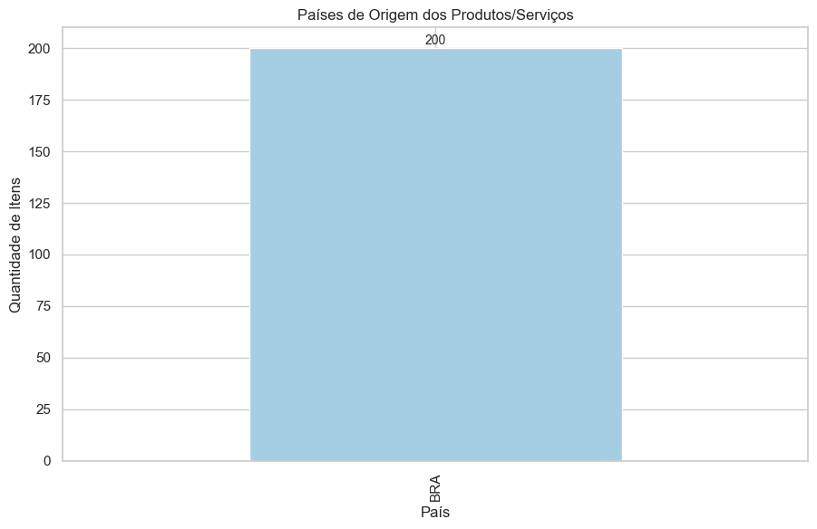

Contagem por codigoPais (ou paisOrigemProdutoServicoId) e plot dos principais países.